# PA1_Template.rmd

Carolina Frias

Monday, January 12, 2015

## Reproductible Data - Course Project 1

### Loading and preprocessing data

Read the data using read.csv():

```r
data <- read.csv("C:/Users/Carolina/Desktop/R/activity.csv", head=TRUE, na.strings="NA")
data$date <- as.Date(data$date)
```

### What is mean total number of steps taken per day?

Sum of steps by day:

```r
subdata <- subset(data, !is.na(data$steps))
dailysteps <- tapply(subdata$steps, subdata$date, sum, na.rm=TRUE, simplify=T)
dailysteps <- dailysteps[!is.na(dailysteps)]
```

Histogram of number of steps taken each day (using base graphics):

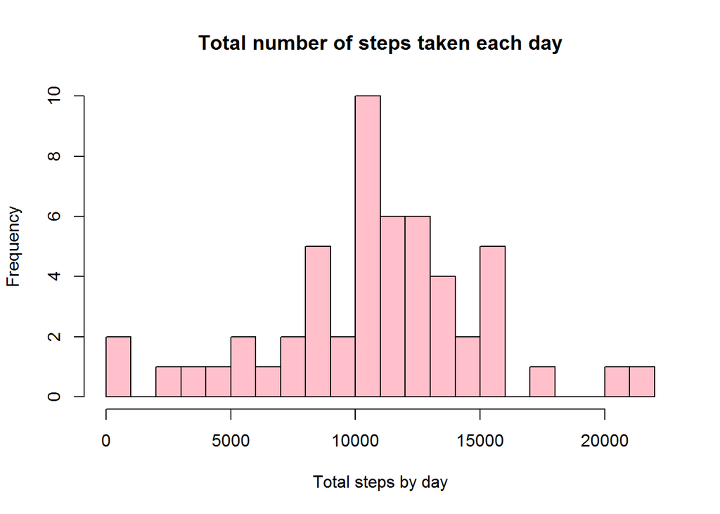

```r
hist(x=dailysteps,
       col="pink",
       breaks=20,
       xlab="Total steps by day",
       ylab="Frequency",
       main = "Total number of steps taken each day")
```

Mean of steps taken by day:

```r
mean(dailysteps)
```

```
## [1] 10766.19
```

Median of steps taken by day:

```r
median(dailysteps)
```

```
## [1] 10765
```

We can see that the mean and median of the total number of steps taken each day are very similar, and the histogram **resemble** a normal distribution.

### What is the average daily activity pattern?

Average daily activity pattern:

```r
average <- tapply(subdata$steps, subdata$interval, mean, na.rm=TRUE, simplify=T)
daily_act <- data.frame(interval=as.integer(names(average)), avg=average)
```

Time series plot of the 5-minute interval and the average number of steps taken, averaged across all days:

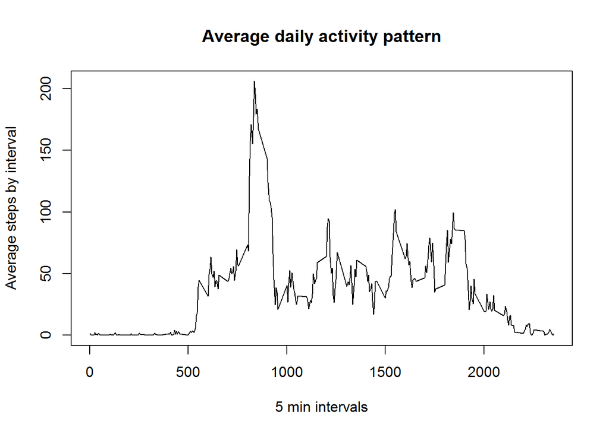

```r
with(daily_act,
       plot(interval,
            avg,
            type="l",
            xlab = "5 min intervals",
            ylab = "Average steps by interval",
            main = "Average daily activity pattern"))
```

Which 5-minute interval, on average across all the days in the dataset, contains the maximum number of steps?

```r
max_steps <- max(daily_act$avg)
daily_act[daily_act$avg == max_steps, ]
```

```
##     interval      avg
## 835      835 206.1698
```

### Imputing missing values

What is the total number of missing values in the dataset?

```r
sum(is.na(data$steps))
```

```
## [1] 2304
```

The total number os NA’s in the dataset is 2304.

Use the mean of the 5 min interval to replace the missing values and create a new dataset:

```r
data_na <- data
new_steps <- is.na(data_na$steps)
average <- tapply(subdata$steps, subdata$interval, mean, na.rm=TRUE, simplify=T)
data_na$steps[new_steps] <- average[as.character(data_na$interval[new_steps])]
```

Histogram of the total number of steps taken each day:

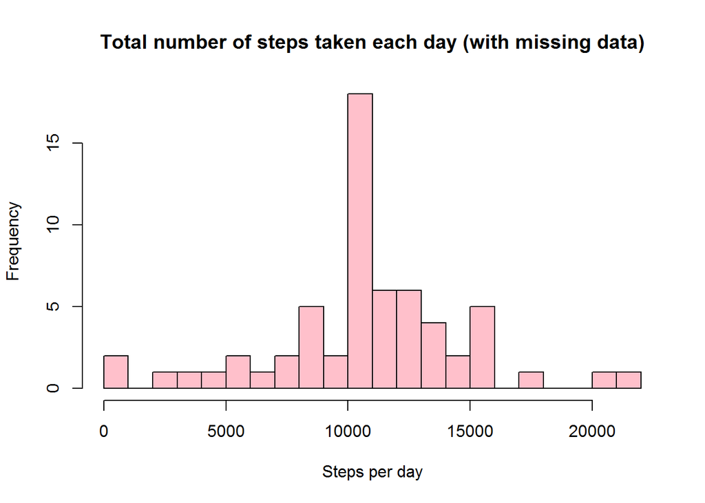

```r
new_daily <- tapply(data_na$steps, data_na$date, sum, na.rm=TRUE, simplify=T)
hist(x=new_daily,
       col="pink",
       breaks=20,
       xlab="Steps per day",
       ylab="Frequency",
       main="Total number of steps taken each day (with missing data)")
```

Mean and median total number of steps taken per day, with missing values imputed:

```r
mean(new_daily)
```

```
## [1] 10766.19
```

```r
median(new_daily)
```

```
## [1] 10766.19
```

Do these values differ from the estimates from the first part of the assignment?

The mean is still the same, but the median is now exactly the same as the mean.

What is the impact of imputing missing data on the estimates of the total daily number of steps?

With the missing values the distribution is now closer to a normal distribution and the mean and median have the same value.

```r
is_weekday <- function(d) {
        wd <- weekdays(d)
        ifelse (wd == "Saturday" | wd == "Sunday", "weekend", "weekday")
}
```

```r
wx <- sapply(data_na$date, is_weekday)
```

```r
data_na$wk <- as.factor(wx)
```

```r
week_data <- aggregate(steps ~ wk+interval, data=data_na, FUN=mean)
library(lattice)
```

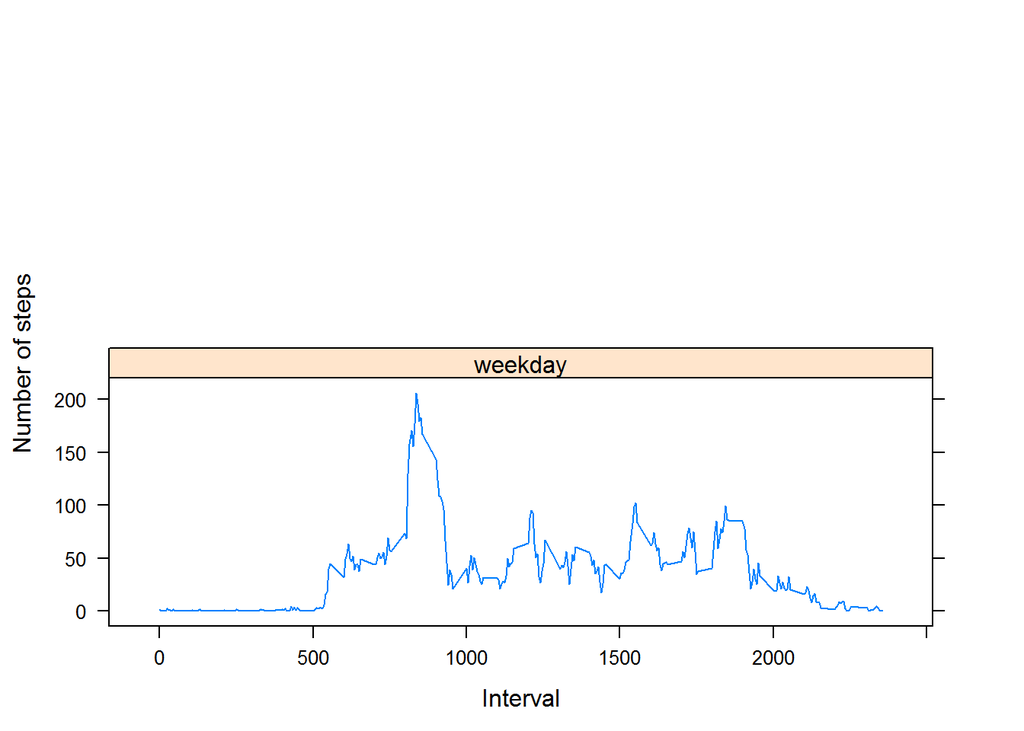

```r
xyplot(steps ~ interval | factor(wk),
         layout = c(1, 2),
         xlab="Interval",
         ylab="Number of steps",
         type="l",
         lty=1,
         data=week_data)
```